# The study to Predict the Price of Houses in Boston

Kiseong Park; Doctor, Data scientist

Monday, April 15, 2019

This study to predict the price of houses in Boston. It aims to practice some regression models in R.

The used data in this study was from well-known as ‘boston housing data’(http://archive.ics.uci.edu/ml/machine-learning-databases/housing/).

```r
bh <- read.csv("E:/AI/projects/boston/boston_housing.csv")
glimpse(bh)
```

```
Observations: 506
Variables: 14
$ CRIM    <dbl> 0.00632, 0.02731, 0.02729, 0.03237, 0.06905, 0.02985, 0.08829, 0.14455, 0.21124, 0...
$ ZN      <dbl> 18.0, 0.0, 0.0, 0.0, 0.0, 0.0, 12.5, 12.5, 12.5, 12.5, 12.5, 12.5, 12.5, 0.0, 0.0,...
$ INDUS   <dbl> 2.31, 7.07, 7.07, 2.18, 2.18, 2.18, 7.87, 7.87, 7.87, 7.87, 7.87, 7.87, 7.87, 8.14...
$ CHAS    <int> 0, 0, 0, 0, 0, 0, 0, 0, 0, 0, 0, 0, 0, 0, 0, 0, 0, 0, 0, 0, 0, 0, 0, 0, 0, 0, 0, 0...
$ NOX     <dbl> 0.538, 0.469, 0.469, 0.458, 0.458, 0.458, 0.524, 0.524, 0.524, 0.524, 0.524, 0.524...
$ RM      <dbl> 6.575, 6.421, 7.185, 6.998, 7.147, 6.430, 6.012, 6.172, 5.631, 6.004, 6.377, 6.009...
$ AGE     <dbl> 65.2, 78.9, 61.1, 45.8, 54.2, 58.7, 66.6, 96.1, 100.0, 85.9, 94.3, 82.9, 39.0, 61....
$ DIS     <dbl> 4.0900, 4.9671, 4.9671, 6.0622, 6.0622, 6.0622, 5.5605, 5.9505, 6.0821, 6.5921, 6....
$ RAD     <int> 1, 2, 2, 3, 3, 3, 5, 5, 5, 5, 5, 5, 5, 4, 4, 4, 4, 4, 4, 4, 4, 4, 4, 4, 4, 4, 4, 4...
$ TAX     <int> 296, 242, 242, 222, 222, 222, 311, 311, 311, 311, 311, 311, 311, 307, 307, 307, 30...
$ PTRATIO <dbl> 15.3, 17.8, 17.8, 18.7, 18.7, 18.7, 15.2, 15.2, 15.2, 15.2, 15.2, 15.2, 15.2, 21.0...
$ B       <dbl> 396.90, 396.90, 392.83, 394.63, 396.90, 394.12, 395.60, 396.90, 386.63, 386.71, 39...
$ LSTAT   <dbl> 4.98, 9.14, 4.03, 2.94, 5.33, 5.21, 12.43, 19.15, 29.93, 17.10, 20.45, 13.27, 15.7...
$ MEDV    <dbl> 24.0, 21.6, 34.7, 33.4, 36.2, 28.7, 22.9, 27.1, 16.5, 18.9, 15.0, 18.9, 21.7, 20.4...
```

As you see, it has 506 observastions and 14 variables.

We can find the meaning of each values in ‘housing.names’ which can be downloaded from website I already mentiond.

`CRIM` is per capita crime rate by town.  
`ZN` is proportion of residential land zoned for lots over 25,000 sq.ft.  
`INDUS` is proportion of non-retail business acres per town.  
`CHAS` is Charles River dummy variable (= 1 if tract bounds river; 0 otherwise).  
`NOX` is nitric oxides concentration (parts per 10 million).  
`RM` is average number of rooms per dwelling.  
`AGE` is proportion of owner-occupied units built prior to 1940.  
`DIS` is weighted distances to five Boston employment centres.  
`RAD` is index of accessibility to radial highways.  
`TAX` is full-value property-tax rate per $10,000.  
`PTRATIO` is pupil-teacher ratio by town.  
`B` is 1000(Bk - 0.63)^2 where Bk is the proportion of blacks by town.  
`LSTAT` is % lower status of the population.  
`MEDV` is Median value of owner-occupied homes in $1000’s.

```r
summary(bh)
```

```
      CRIM                ZN             INDUS            CHAS              NOX
 Min.   : 0.00632   Min.   :  0.00   Min.   : 0.46   Min.   :0.00000   Min.   :0.3850
 1st Qu.: 0.08204   1st Qu.:  0.00   1st Qu.: 5.19   1st Qu.:0.00000   1st Qu.:0.4490
 Median : 0.25651   Median :  0.00   Median : 9.69   Median :0.00000   Median :0.5380
 Mean   : 3.61352   Mean   : 11.36   Mean   :11.14   Mean   :0.06917   Mean   :0.5547
 3rd Qu.: 3.67708   3rd Qu.: 12.50   3rd Qu.:18.10   3rd Qu.:0.00000   3rd Qu.:0.6240
 Max.   :88.97620   Max.   :100.00   Max.   :27.74   Max.   :1.00000   Max.   :0.8710
       RM             AGE              DIS              RAD              TAX           PTRATIO
 Min.   :3.561   Min.   :  2.90   Min.   : 1.130   Min.   : 1.000   Min.   :187.0   Min.   :12.60
 1st Qu.:5.886   1st Qu.: 45.02   1st Qu.: 2.100   1st Qu.: 4.000   1st Qu.:279.0   1st Qu.:17.40
 Median :6.208   Median : 77.50   Median : 3.207   Median : 5.000   Median :330.0   Median :19.05
 Mean   :6.285   Mean   : 68.57   Mean   : 3.795   Mean   : 9.549   Mean   :408.2   Mean   :18.46
 3rd Qu.:6.623   3rd Qu.: 94.08   3rd Qu.: 5.188   3rd Qu.:24.000   3rd Qu.:666.0   3rd Qu.:20.20
 Max.   :8.780   Max.   :100.00   Max.   :12.127   Max.   :24.000   Max.   :711.0   Max.   :22.00
       B              LSTAT            MEDV
 Min.   :  0.32   Min.   : 1.73   Min.   : 5.00
 1st Qu.:375.38   1st Qu.: 6.95   1st Qu.:17.02
 Median :391.44   Median :11.36   Median :21.20
 Mean   :356.67   Mean   :12.65   Mean   :22.53
 3rd Qu.:396.23   3rd Qu.:16.95   3rd Qu.:25.00
 Max.   :396.90   Max.   :37.97   Max.   :50.00
```

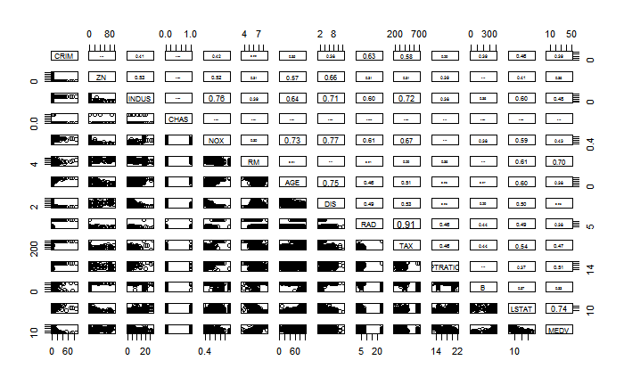

```r
pairs(bh, lower.panel = points, upper.panel = panel.cor)
```

This scatter plots show `MEDV` has strong correlation with `RM` and `LSTAT`.

## Dividing into 3 groups; training, validation, and test

| N.training | N.validation | N.test |
| --- | --- | --- |
| 303 | 102 | 101 |

I divided boston housing data into 3 groups for training, validation, and test.  
Training set has 303, validation set has 102, and test set has 101 observastions.

## Linear regression

```r
bh_lm <- lm(MEDV ~ ., bh)
bh_lm %>% summary()
```

```
Call:
lm(formula = MEDV ~ ., data = bh)

Residuals:
    Min      1Q  Median      3Q     Max
-15.595  -2.730  -0.518   1.777  26.199

Coefficients:
              Estimate Std. Error t value Pr(>|t|)
(Intercept)  3.646e+01  5.103e+00   7.144 3.28e-12 ***
CRIM        -1.080e-01  3.286e-02  -3.287 0.001087 **
ZN           4.642e-02  1.373e-02   3.382 0.000778 ***
INDUS        2.056e-02  6.150e-02   0.334 0.738288
CHAS         2.687e+00  8.616e-01   3.118 0.001925 **
NOX         -1.777e+01  3.820e+00  -4.651 4.25e-06 ***
RM           3.810e+00  4.179e-01   9.116  < 2e-16 ***
AGE          6.922e-04  1.321e-02   0.052 0.958229
DIS         -1.476e+00  1.995e-01  -7.398 6.01e-13 ***
RAD          3.060e-01  6.635e-02   4.613 5.07e-06 ***
TAX         -1.233e-02  3.760e-03  -3.280 0.001112 **
PTRATIO     -9.527e-01  1.308e-01  -7.283 1.31e-12 ***
B            9.312e-03  2.686e-03   3.467 0.000573 ***
LSTAT       -5.248e-01  5.072e-02 -10.347  < 2e-16 ***
---
Signif. codes:  0 ‘***’ 0.001 ‘**’ 0.01 ‘*’ 0.05 ‘.’ 0.1 ‘ ’ 1

Residual standard error: 4.745 on 492 degrees of freedom
Multiple R-squared:  0.7406,    Adjusted R-squared:  0.7338
F-statistic: 108.1 on 13 and 492 DF,  p-value: < 2.2e-16
```

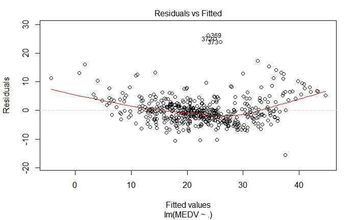

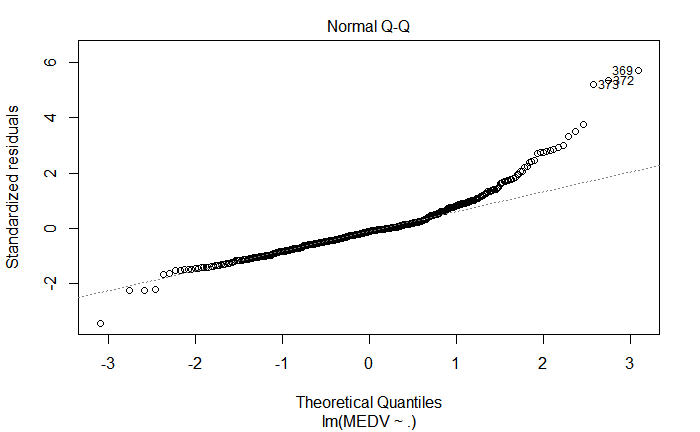

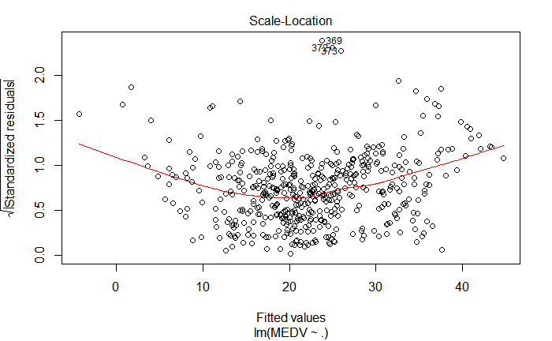

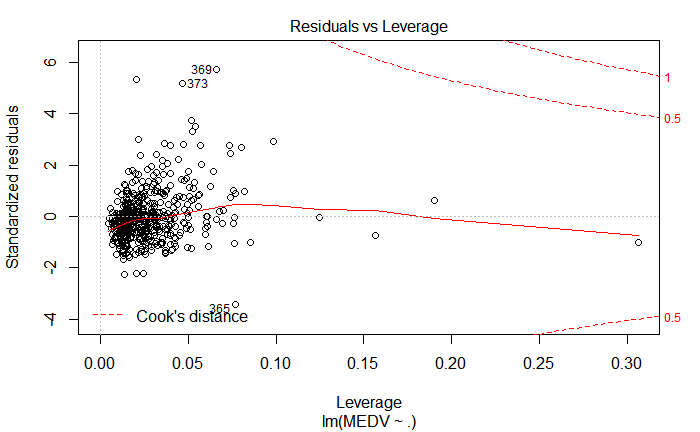

```r
bh_lm %>% plot()
```

We can find non-linear correlation in ‘Residuals vs Fitted values’ plot of linear regression model.  
But it shows a graph of quadratic function.  
It seems to match quadratic functions of the variables.

```r
bh_lm2 <- lm(MEDV ~ .^2, bh)
bh_lm2 %>% summary()
```

```
Call:
lm(formula = MEDV ~ .^2, data = bh)

Residuals:
    Min      1Q  Median      3Q     Max
-7.9374 -1.5344 -0.1068  1.2973 17.8500

Coefficients:
                Estimate Std. Error t value Pr(>|t|)
(Intercept)   -1.579e+02  6.800e+01  -2.323 0.020683 *
CRIM          -1.707e+01  6.554e+00  -2.605 0.009526 **
ZN            -7.529e-02  4.580e-01  -0.164 0.869508
INDUS         -2.819e+00  1.696e+00  -1.663 0.097111 .
CHAS           4.451e+01  1.952e+01   2.280 0.023123 *
NOX            2.006e+01  7.516e+01   0.267 0.789717
RM             2.527e+01  5.699e+00   4.435 1.18e-05 ***
AGE            1.263e+00  2.728e-01   4.630 4.90e-06 ***
DIS           -1.698e+00  4.604e+00  -0.369 0.712395
RAD            1.861e+00  2.464e+00   0.755 0.450532
TAX            3.670e-02  1.440e-01   0.255 0.798978
PTRATIO        2.725e+00  2.850e+00   0.956 0.339567
B              9.942e-02  7.468e-02   1.331 0.183833
LSTAT          1.656e+00  8.533e-01   1.940 0.053032 .
CRIM:ZN        4.144e-01  1.804e-01   2.297 0.022128 *
CRIM:INDUS    -4.693e-02  4.480e-01  -0.105 0.916621
CRIM:CHAS      2.428e+00  5.710e-01   4.251 2.63e-05 ***
CRIM:NOX      -1.108e+00  9.285e-01  -1.193 0.233425
CRIM:RM        2.163e-01  4.907e-02   4.409 1.33e-05 ***
CRIM:AGE      -3.083e-03  3.781e-03  -0.815 0.415315
CRIM:DIS      -1.903e-01  1.060e-01  -1.795 0.073307 .
CRIM:RAD      -6.584e-01  5.815e-01  -1.132 0.258198
CRIM:TAX       3.479e-02  4.287e-02   0.812 0.417453
CRIM:PTRATIO   4.915e-01  3.328e-01   1.477 0.140476
CRIM:B        -4.612e-04  1.793e-04  -2.572 0.010451 *
CRIM:LSTAT     2.964e-02  6.544e-03   4.530 7.72e-06 ***
ZN:INDUS      -6.731e-04  4.651e-03  -0.145 0.885000
ZN:CHAS       -5.230e-02  6.450e-02  -0.811 0.417900
ZN:NOX         1.998e-03  4.721e-01   0.004 0.996625
ZN:RM         -7.286e-04  2.602e-02  -0.028 0.977672
ZN:AGE        -1.249e-06  8.514e-04  -0.001 0.998830
```

[output cut: 52 more lines]

```
RAD:PTRATIO   -4.379e-02  8.392e-02  -0.522 0.602121
RAD:B         -4.362e-04  2.518e-03  -0.173 0.862561
RAD:LSTAT     -2.529e-02  1.816e-02  -1.392 0.164530
TAX:PTRATIO    7.854e-03  2.504e-03   3.137 0.001830 **
TAX:B         -4.785e-07  1.999e-04  -0.002 0.998091
TAX:LSTAT     -1.403e-03  1.208e-03  -1.162 0.245940
PTRATIO:B      1.203e-03  3.361e-03   0.358 0.720508
PTRATIO:LSTAT  3.901e-03  2.985e-02   0.131 0.896068
B:LSTAT       -6.118e-04  4.157e-04  -1.472 0.141837
---
Signif. codes:  0 ‘***’ 0.001 ‘**’ 0.01 ‘*’ 0.05 ‘.’ 0.1 ‘ ’ 1

Residual standard error: 2.852 on 414 degrees of freedom
Multiple R-squared:  0.9212,    Adjusted R-squared:  0.9039
F-statistic: 53.18 on 91 and 414 DF,  p-value: < 2.2e-16
```

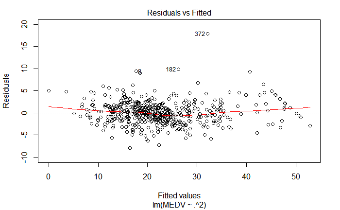

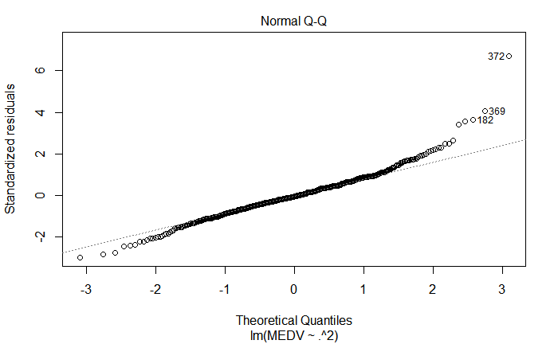

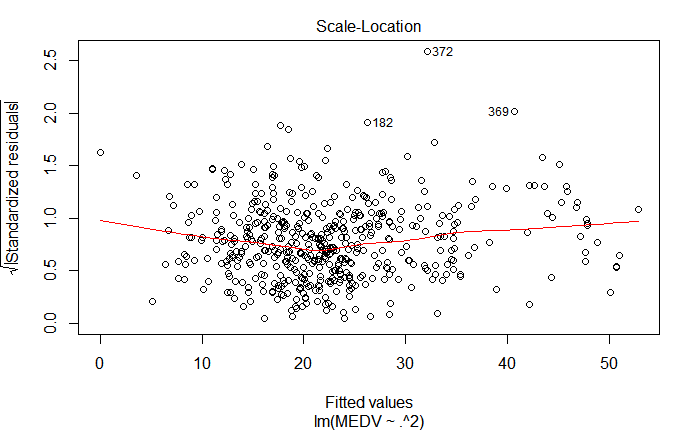

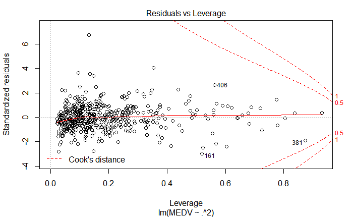

```r
bh_lm2 %>% plot()
```

```r
bh_lm2_step <- stepAIC(bh_lm, scope = list(upper = ~ .^2, lower = ~ 1))
```

```r
bh_lm2_step %>% summary()
```

```
Call:
lm(formula = MEDV ~ CRIM + ZN + INDUS + CHAS + NOX + RM + AGE +
    DIS + RAD + TAX + PTRATIO + B + LSTAT + RM:LSTAT + RAD:LSTAT +
    DIS:RAD + B:LSTAT + CRIM:CHAS + CHAS:NOX + CHAS:RM + CHAS:PTRATIO +
    RM:PTRATIO + AGE:B + ZN:DIS + CRIM:RM + CRIM:LSTAT + CHAS:LSTAT +
    RM:AGE + AGE:LSTAT + RM:B + CRIM:B + CRIM:DIS + ZN:LSTAT +
    ZN:TAX + DIS:LSTAT + TAX:PTRATIO + NOX:RAD + CRIM:ZN + NOX:AGE +
    INDUS:NOX + AGE:RAD + AGE:PTRATIO + AGE:DIS + CHAS:B + AGE:TAX +
    DIS:TAX + CRIM:RAD + INDUS:RM + RM:TAX + TAX:LSTAT + DIS:B +
    CRIM:TAX, data = bh)

Residuals:
    Min      1Q  Median      3Q     Max
-8.0887 -1.4639 -0.1571  1.3588 18.2969

Coefficients:
               Estimate Std. Error t value Pr(>|t|)
(Intercept)  -1.966e+02  2.109e+01  -9.320  < 2e-16 ***
CRIM         -3.850e+00  2.579e+00  -1.493 0.136210
ZN           -1.239e-01  4.605e-02  -2.691 0.007381 **
INDUS        -3.789e+00  6.058e-01  -6.255 9.19e-10 ***
CHAS          5.714e+01  1.197e+01   4.773 2.45e-06 ***
NOX           1.669e+01  1.240e+01   1.346 0.179026
RM            3.145e+01  2.453e+00  12.821  < 2e-16 ***
AGE           1.345e+00  1.805e-01   7.452 4.70e-13 ***
DIS           2.477e+00  1.626e+00   1.523 0.128530
RAD           8.232e-01  3.877e-01   2.124 0.034250 *
TAX           1.006e-01  3.436e-02   2.929 0.003576 **
PTRATIO       1.986e+00  9.762e-01   2.035 0.042437 *
B             1.233e-01  2.664e-02   4.630 4.79e-06 ***
LSTAT         2.702e+00  3.447e-01   7.839 3.28e-14 ***
RM:LSTAT     -3.097e-01  3.680e-02  -8.417 5.13e-16 ***
RAD:LSTAT    -2.381e-02  8.201e-03  -2.903 0.003879 **
DIS:RAD      -6.200e-02  3.992e-02  -1.553 0.121129
B:LSTAT      -8.247e-04  3.583e-04  -2.301 0.021824 *
CRIM:CHAS     2.311e+00  3.674e-01   6.291 7.42e-10 ***
CHAS:NOX     -2.914e+01  6.332e+00  -4.603 5.42e-06 ***
CHAS:RM      -5.604e+00  9.795e-01  -5.722 1.92e-08 ***
CHAS:PTRATIO -8.371e-01  3.687e-01  -2.270 0.023665 *
RM:PTRATIO   -5.255e-01  1.185e-01  -4.433 1.17e-05 ***
```

[output cut: 21 more lines]

```
CHAS:B        2.937e-02  1.186e-02   2.477 0.013610 *
AGE:TAX      -2.940e-04  1.567e-04  -1.877 0.061190 .
DIS:TAX      -4.152e-03  1.809e-03  -2.295 0.022190 *
CRIM:RAD     -2.923e-01  1.342e-01  -2.178 0.029951 *
INDUS:RM      3.821e-01  7.576e-02   5.044 6.60e-07 ***
RM:TAX       -2.646e-02  3.270e-03  -8.093 5.41e-15 ***
TAX:LSTAT    -1.293e-03  4.822e-04  -2.681 0.007613 **
DIS:B        -5.566e-03  3.556e-03  -1.565 0.118268
CRIM:TAX      1.416e-02  8.524e-03   1.661 0.097351 .
---
Signif. codes:  0 ‘***’ 0.001 ‘**’ 0.01 ‘*’ 0.05 ‘.’ 0.1 ‘ ’ 1

Residual standard error: 2.796 on 453 degrees of freedom
Multiple R-squared:  0.9171,    Adjusted R-squared:  0.9076
F-statistic: 96.38 on 52 and 453 DF,  p-value: < 2.2e-16
```

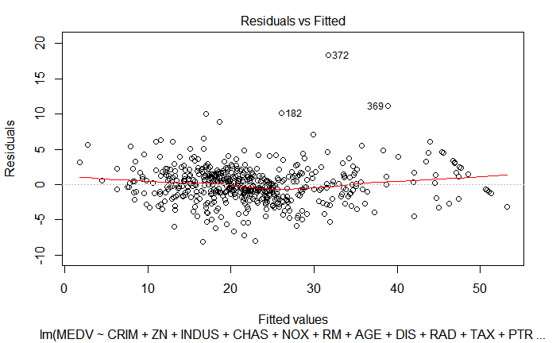

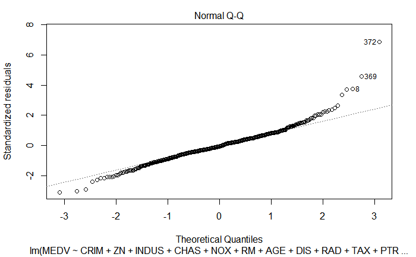

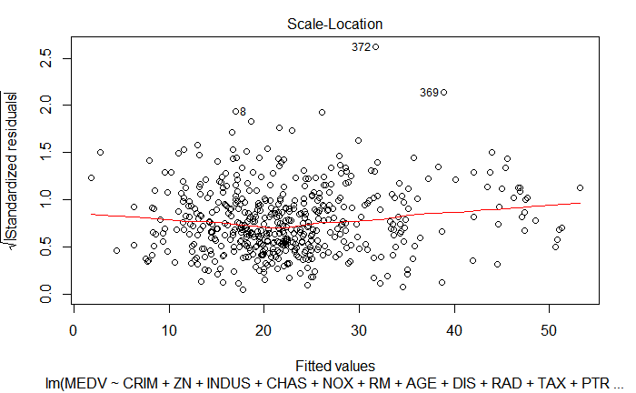

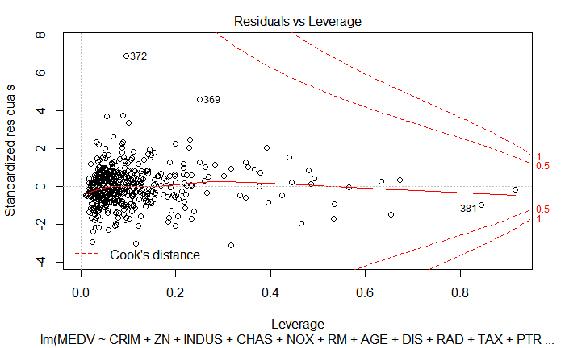

```r
bh_lm2_step %>% plot()
```

```r
length(bh_lm2_step$coef)
```

```
[1] 53
```

```r
yhat_lm <- predict(bh_lm, newdata = validation)
yhat_lm2 <- predict(bh_lm2, newdata = validation)
yhat_lm2_step <- predict(bh_lm2_step, newdata = validation)
rmse_lm <- rmse(y_obs, yhat_lm)
rmse_lm2 <- rmse(y_obs, yhat_lm2)
rmse_lm2_step <- rmse(y_obs, yhat_lm2_step)
df_LM <- data.frame(Method = c('LM', 'LM2', 'STEP'), RMSE = c(rmse_lm, rmse_lm2, rmse_lm2_step))
df_LM
```

| Method | RMSE |
| --- | --- |
| LM | 4.424843 |
| LM2 | 2.465043 |
| STEP | 2.557422 |

## Lasso Regression

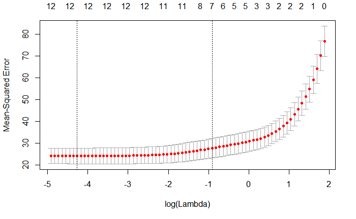

```r
library(glmnet)
training.x <- model.matrix(MEDV ~ .-1, training)
training.y <- training$MEDV
bh_lasso <- cv.glmnet(training.x, training.y)
bh_lasso %>% plot()
```

```r
validation.x <- model.matrix(MEDV ~ .-1, validation)
yhat_lasso <- predict(bh_lasso, s='lambda.min', newx = validation.x)
rmse_Lasso <- rmse(y_obs, yhat_lasso)
df_Lasso <- data.frame(Method = 'Lasso', RMSE = rmse_Lasso)
df_Lasso
```

| Method | RMSE |
| --- | --- |
| Lasso | 4.845355 |

## Ridge Regression

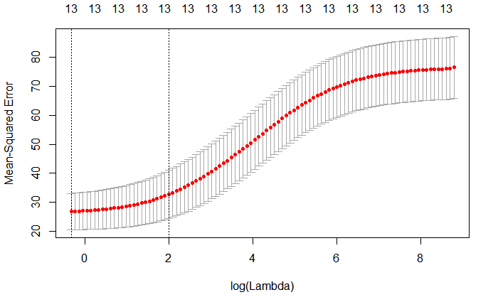

```r
bh_ridge <- cv.glmnet(training.x, training.y, alpha = 0)
bh_ridge %>% plot()
```

```r
yhat_ridge <- predict(bh_ridge, newx = validation.x)
yhat_ridge <- yhat_ridge[,1]
rmse_ridge <- rmse(y_obs, yhat_ridge)
df_Ridge <- data.frame(Method = 'Ridge', RMSE = rmse_ridge)
df_Ridge
```

| Method | RMSE |
| --- | --- |
| Ridge | 5.132822 |

## Elastir Regression

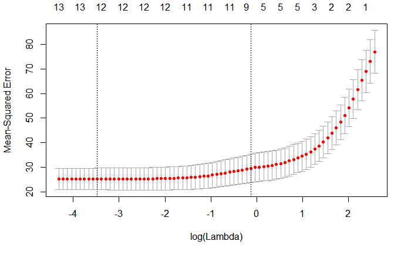

```r
bh_elastic <- cv.glmnet(training.x, training.y, alpha=0.5)
bh_elastic %>% plot()
```

```r
yhat_elastic <- predict(bh_elastic, s='lambda.min', newx = validation.x)
yhat_elastic <- yhat_elastic[,1]
rmse_elastic <- rmse(y_obs, yhat_elastic)
df_elastic <- data.frame(Method = 'Elastic', RMSE = rmse_elastic)
df_elastic
```

| Method | RMSE |
| --- | --- |
| Elastic | 4.83844 |

## Regression Tree

```r
library(rpart)
bh_rt <- rpart(MEDV ~ ., training)
printcp(bh_rt)
```

```
Regression tree:
rpart(formula = MEDV ~ ., data = training)

Variables actually used in tree construction:
[1] AGE   LSTAT NOX   RM

Root node error: 23192/303 = 76.542

n= 303

        CP nsplit rel error  xerror     xstd
1 0.419939      0   1.00000 1.01166 0.110294
2 0.174483      1   0.58006 0.66795 0.071839
3 0.081877      2   0.40558 0.45017 0.049794
4 0.035094      3   0.32370 0.38589 0.048988
5 0.034412      4   0.28861 0.42132 0.055740
6 0.018127      6   0.21978 0.37509 0.055356
7 0.012553      7   0.20166 0.36526 0.059784
8 0.010000      8   0.18910 0.35767 0.059798
```

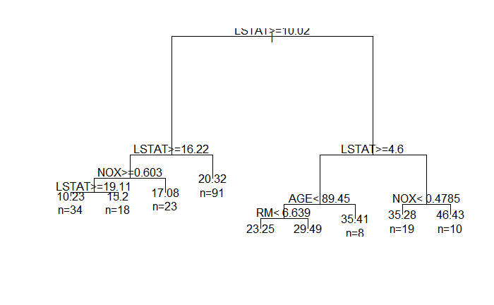

```r
bh_rt %>% plot(); text(bh_rt, use.n = T)
```

```r
yhat_rt <- predict(bh_rt, newdata = validation)
rmse_rt <- rmse(y_obs, yhat_rt)
df_RT <- data.frame(Method = 'RT', RMSE = rmse_rt)
df_RT
```

| Method | RMSE |
| --- | --- |
| RT | 5.101097 |

## RandomForest

```r
library(randomForest)
set.seed(0415)
bh_rf <- randomForest(MEDV ~ ., training)
bh_rf
```

```
Call:
 randomForest(formula = MEDV ~ ., data = training)
               Type of random forest: regression
                     Number of trees: 500
No. of variables tried at each split: 4

          Mean of squared residuals: 13.81031
                    % Var explained: 81.96
```

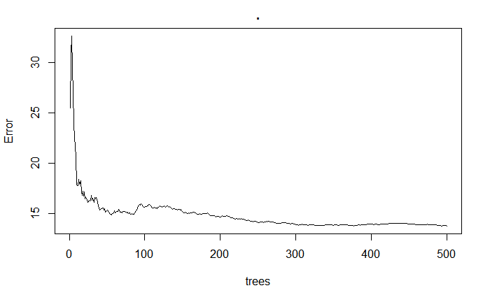

```r
bh_rf %>% plot()
```

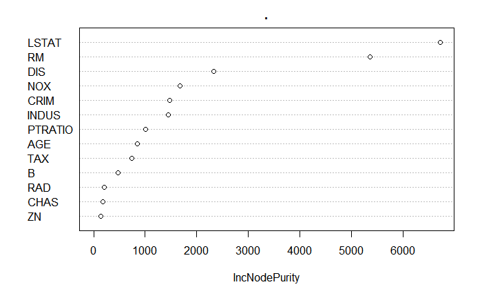

```r
bh_rf %>% varImpPlot()
```

```r
yhat_rf <- predict(bh_rf, newdata = validation)
rmse_rf <- rmse(y_obs, yhat_rf)
df_RF <- data.frame(Method='RF', RMSE=rmse_rf)
df_RF
```

| Method | RMSE |
| --- | --- |
| RF | 3.387829 |

## Gradient Boosting Machine

```r
library(gbm)
set.seed(0415)
bh_gbm <- gbm(MEDV ~ ., data=training, n.trees = 1000, cv.folds = 3, verbose = T)
```

```
Distribution not specified, assuming gaussian ...
```

```r
bh_gbm
```

```
gbm(formula = MEDV ~ ., data = training, n.trees = 1000, cv.folds = 3,
    verbose = T)
A gradient boosted model with gaussian loss function.
1000 iterations were performed.
The best cross-validation iteration was 471.
There were 13 predictors of which 12 had non-zero influence.
```

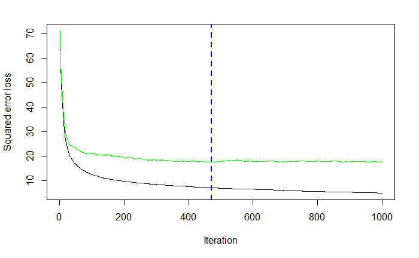

```r
best_iter <- gbm.perf(bh_gbm, method='cv')
```

```r
yhat_gbm <- predict(bh_gbm, n.trees = best_iter, newdata = validation)
rmse_gbm <- rmse(y_obs, yhat_gbm)
df_GBM <- data.frame(Method='GBM', RMSE = rmse_gbm)
df_GBM
```

| Method | RMSE |
| --- | --- |
| GBM | 3.723828 |

## Model Selection

```r
df_result <- rbind(df_LM, df_Lasso, df_Ridge, df_elastic, df_RT, df_RF, df_GBM)
df_result[order(df_result$RMSE),]
```

|  | Method | RMSE |
| --- | --- | --- |
| 2 | LM2 | 2.465043 |
| 3 | STEP | 2.557422 |
| 8 | RF | 3.387829 |
| 9 | GBM | 3.723828 |
| 1 | LM | 4.424843 |
| 6 | Elastic | 4.838440 |
| 4 | Lasso | 4.845355 |
| 7 | RT | 5.101097 |
| 5 | Ridge | 5.132822 |

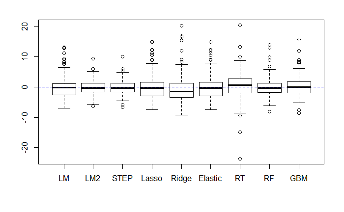

```r
boxplot(list(LM = y_obs - yhat_lm,
        LM2 = y_obs - yhat_lm2,
        STEP = y_obs - yhat_lm2_step,
        Lasso = y_obs - yhat_lasso,
        Ridge = y_obs - yhat_ridge,
        Elastic = y_obs - yhat_elastic,
        RT = y_obs - yhat_rt,
        RF = y_obs - yhat_rf,
        GBM = y_obs - yhat_gbm))
abline(h = 0, lty=2, col='blue')
```

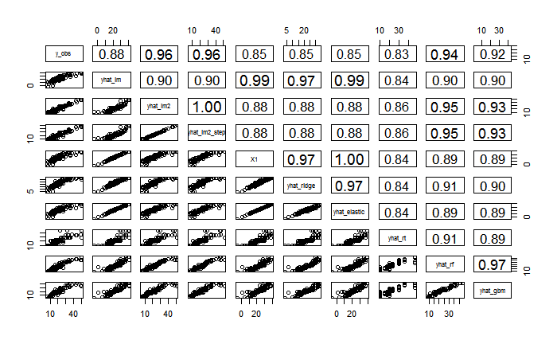

```r
pairs(data.frame(y_obs, yhat_lm, yhat_lm2, yhat_lm2_step, yhat_lasso, yhat_ridge, yhat_elastic, yhat_rt, yhat_rf, yhat_gbm), upper.panel = panel.cor)
```

## Test

```r
y_test <- test$MEDV
yhat_lm2_test <- predict(bh_lm2, newdata = test)
rmse_lm2_test <- rmse(y_test, yhat_lm2_test)
yhat_step_test <- predict(bh_lm2_step, newdata = test)
rmse_step_test <- rmse(y_test, yhat_step_test)
data.frame(Method=c('LM2','Step'),RMSE=c(rmse_lm2_test, rmse_step_test))
```

| Method | RMSE |
| --- | --- |
| LM2 | 2.430609 |
| Step | 2.344168 |